# Análise sobre a popularidade de algumas linguagens de programação.

Valter Lucena

13 de julho de 2018

Nesta análise, nosso objetivo é entender um pouco mais sobre a popularidade de linguagens de programação durante a semana e durante os fins de semana.

# Dados

Primeiramente, vamos importar nossos dados, que são uma amostra da atividade global do Github.

```r
modificacoes = readr::read_csv(here("data/github-users-committing-filetypes.csv"))

modificacoes %>% names(.)
```

```
## [1] "file_extension" "month_day"      "the_month"      "the_year"
## [5] "users"
```

Cada observação na base de dados representa um dia do ano entre 2016 e 2017, e informam quantos usuários fizeram modificações para uma determinada extensão de arquivo naquele dia. Vamos ver agora sobre quais extensões de arquivos temos informação, e quantas observações temos sobre cada uma.

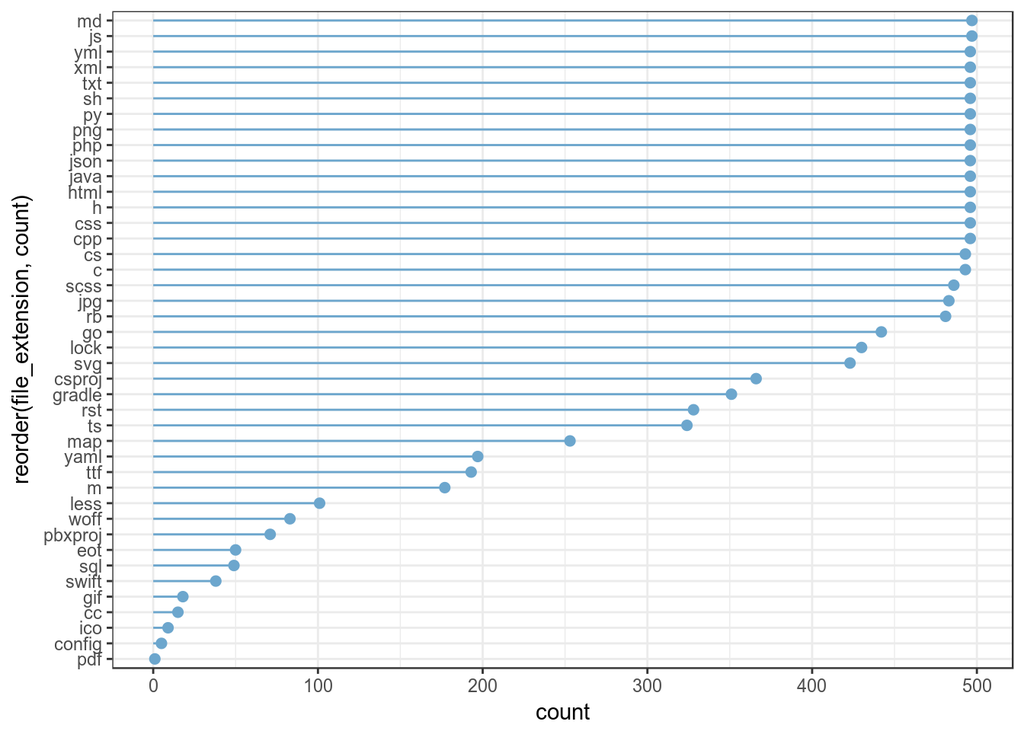

```r
modificacoes %>%
  group_by(file_extension) %>%
  summarise(count = n()) %>%
  ggplot(aes(x = reorder(file_extension, count),
             y = count)) +
  geom_point(size = 2,
             colour = "skyblue3") +
  geom_segment(aes(x = file_extension,
                   xend = file_extension,
                   y = 0,
                   yend = count),
               colour = "skyblue3") +
  coord_flip()
```

Podemos utilizar destas informações sobre essas extensões para analisar a popularidade de linguagens de programação, já que algumas dessas extensões estão relacionadas à linguagens.

**Observação**: A base de dados contém informações sobre edições de arquivos que não são referentes a linguagens de programação, como por exempĺo, `md (markdown)` e `html`, que são linguagens de marcação. Portanto, durante a análise, os resultados referentes a este extensões não serão utilizados como base para as conclusões.

Precisaremos de uma variável na base de dados que nos diga o dia da semana de cada observação.

```r
modificacoes = modificacoes %>%
  mutate(date = paste(the_year,
                      the_month,
                      month_day,
                      sep = "-") %>%
           as.Date(.)) %>%
  mutate(weekday = weekdays(as.Date(date))) %>%
  mutate(is_weekend = ifelse(weekday %in% c("sábado",
                                            "domingo"),
                             TRUE,
                             FALSE))
```

# Perguntas

Durante a análise tentaremos responder às seguintes perguntas:

1. Quais as linguagens mais populares durante a época de festas juninas?
- Mudando a medida de popularidade, a conclusão se mantém a mesma?
2. Se considerarmos que durante o fim de semana os desenvolvedores geralmente dedicam-se a projetos pessoais em outras linguagens para desenvolvimento de habilidades, podemos utilizar o mesmo raciocínio para os períodos de férias?

## Quais as linguagens mais populares durante a época de festas juninas?

Para algumas regiões do Brasil, principalmente para o nordeste, às festividades do mês de junho mudam um pouco da rotina das pessoas. Sabendo que os dados que possuímos são sobre modificações feitas em todo o mundo, podemos supor que algumas dessas modificações foram realizadas também por aqui. Vejamos, então, qual a linguagem mais popular durante o mês de junho.

Para isso, iremos considerar apenas as modificações do mês de junho do ano de 2016 para as linguagens Python, Java, C e C++, algumas das mais utilizadas de acordo com o gráfico anterior, e utilizaremos a média de usuários como medida de popularidade.

```r
modificacoes.linguagens = modificacoes %>%
  filter(file_extension %in% c("py", "java", "c", "cpp"),
         the_month == 6,
         the_year == 2016)
```

Como possuímos apenas uma amostra da atividade global do Github, utilizaremos uma técnica de inferência chamada de **bootstrap** para coletar informações da amostra e utilizar como base para criar nossas conclusões sobre a popularidade das linguagens durante o mês de junho de 2016. Utilizaremos a média da quantidade de usuários da linguagem como estatística para isso.

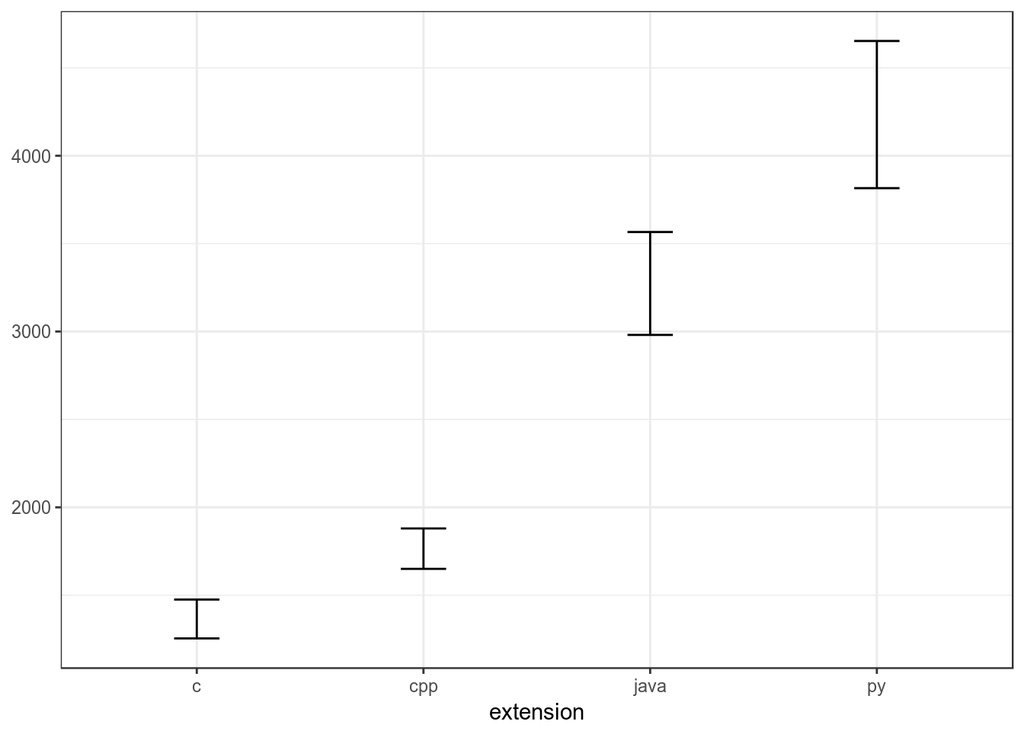

```r
ci.mean.py = modificacoes.linguagens %>%
  filter(file_extension %in% c("py")) %>%
  bootstrap(mean(users)) %>%
  CI.percentile(probs = c(0.025, 0.975))

ci.mean.java = modificacoes.linguagens %>%
  filter(file_extension %in% c("java")) %>%
  bootstrap(mean(users)) %>%
  CI.percentile(probs = c(0.025, 0.975))

ci.mean.c = modificacoes.linguagens %>%
  filter(file_extension %in% c("c")) %>%
  bootstrap(mean(users)) %>%
  CI.percentile(probs = c(0.025, 0.975))

ci.mean.cpp = modificacoes.linguagens %>%
  filter(file_extension %in% c("cpp")) %>%
  bootstrap(mean(users)) %>%
  CI.percentile(probs = c(0.025, 0.975))

mean.df = data.frame(rbind(ci.mean.py,
                           ci.mean.java,
                           ci.mean.cpp,
                           ci.mean.c))

mean.df$extension = c("py",
                      "java",
                      "cpp",
                      "c")

mean.df %>%
  ggplot(aes(x = extension,
             ymin = X2.5.,
             ymax = X97.5.)) +
  geom_errorbar(width = .2)
```

Aqui, podemos observar que não há interseção entre nenhum dos intervalos de confiança para a média de usuários dessas linguagens durante as épocas juninas. Portanto, podemos afirmar que Python é a linguagem mais utilizada durante junho de 2016.

### Mudando a medida de popularidade, a conclusão se mantém a mesma?

Vamos verificar se utilizando a mediana chegamos nos mesmos resultados.

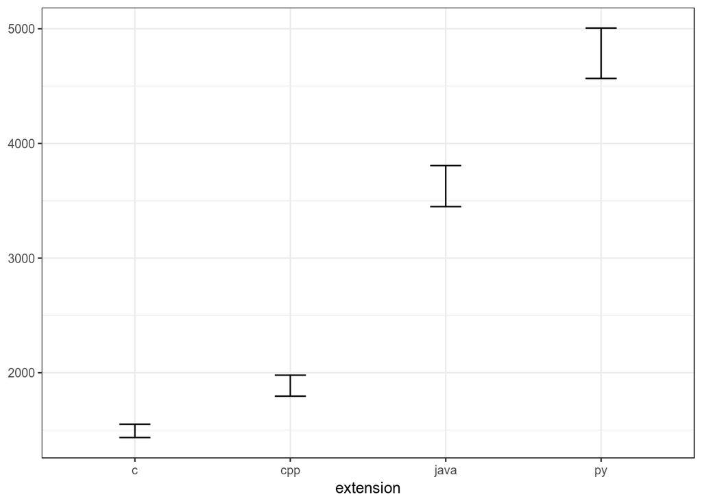

```r
ci.median.py = modificacoes.linguagens %>%
  filter(file_extension %in% c("py")) %>%
  bootstrap(median(users)) %>%
  CI.percentile(probs = c(0.025, 0.975))

ci.median.java = modificacoes.linguagens %>%
  filter(file_extension %in% c("java")) %>%
  bootstrap(median(users)) %>%
  CI.percentile(probs = c(0.025, 0.975))

ci.median.c = modificacoes.linguagens %>%
  filter(file_extension %in% c("c")) %>%
  bootstrap(median(users)) %>%
  CI.percentile(probs = c(0.025, 0.975))

ci.median.cpp = modificacoes.linguagens %>%
  filter(file_extension %in% c("cpp")) %>%
  bootstrap(median(users)) %>%
  CI.percentile(probs = c(0.025, 0.975))

median.df = data.frame(rbind(ci.median.py,
                           ci.median.java,
                           ci.median.cpp,
                           ci.median.c))

median.df$extension = c("py",
                      "java",
                      "cpp",
                      "c")

median.df %>%
  ggplot(aes(x = extension,
             ymin = X2.5.,
             ymax = X97.5.)) +
  geom_errorbar(width = .2)
```

Utilizando a mediana da quantidade de usuários da linguagem como medida de popularidade, mantemos a conclusão de que Python foi a linguagem mais utilizada durante o mês de junho de 2016.

## Se considerarmos que durante o fim de semana os desenvolvedores geralmente dedicam-se a projetos pessoais em outras linguagens para desenvolvimento de habilidades, podemos utilizar o mesmo raciocínio para os períodos de férias?

Para responder essa pergunta, utilizaremos apenas os dados referentes às linguagens Ruby, Go e Swift. Essas linguagens estão se popularizando, mas ainda não são tão utilizadas como as linguagens citadas no exercício anterior. Por isso, é possível supôr que essas pessoas podem utilizar de períodos como férias ou finais de semana para se dedicar um pouco mais ao aprendizado dessas linguagens, sem atrapalhar as atividades durante o resto dos dias do ano.

Primeiramente, vamos traçar uma linha do tempo da quantidade de usuários que utilizaram essas linguagens.

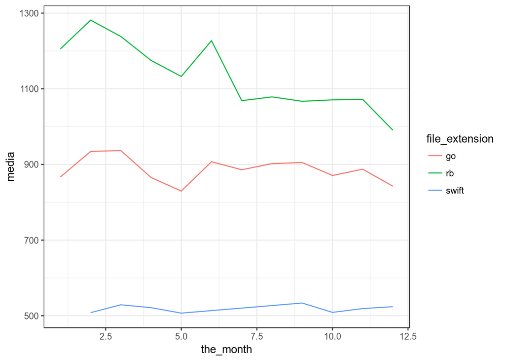

```r
modificacoes.outras = modificacoes %>%
  filter(file_extension %in% c("rb", "go", "swift")) %>%
  mutate(ferias = ifelse(the_month %in% c(1, 12),
                         "ferias",
                         "normal"))

modificacoes.outras %>%
  filter(the_month %in% c(1, 2, 3, 4, 5, 6, 7, 8, 9, 10, 11, 12)) %>%
  group_by(file_extension, the_month) %>%
  summarise(media = mean(users)) %>%
  ggplot(aes(x = the_month,
             y = media,
             colour = file_extension)) +
  geom_line()
```

```r
ci.normal.go = modificacoes.outras %>%
  filter(file_extension %in% c("go"),
         the_month %in% c(2, 3, 4, 5, 6, 7, 8, 9, 10, 11)) %>%
  bootstrap(median(users)) %>%
  CI.percentile(probs = c(0.025, 0.975))

ci.ferias.go = modificacoes.outras %>%
  filter(file_extension %in% c("go"),
         the_month %in% c(1, 12)) %>%
  bootstrap(median(users)) %>%
  CI.percentile(probs = c(0.025, 0.975))

ci.normal.rb = modificacoes.outras %>%
  filter(file_extension %in% c("rb"),
         the_month %in% c(2, 3, 4, 5, 6, 7, 8, 9, 10, 11)) %>%
  bootstrap(median(users)) %>%
  CI.percentile(probs = c(0.025, 0.975))

ci.ferias.rb = modificacoes.outras %>%
  filter(file_extension %in% c("rb"),
         the_month %in% c(1, 12)) %>%
  bootstrap(median(users)) %>%
  CI.percentile(probs = c(0.025, 0.975))

ci.normal.swift = modificacoes.outras %>%
  filter(file_extension %in% c("swift"),
         the_month %in% c(2, 3, 4, 5, 6, 7, 8, 9, 10, 11)) %>%
  bootstrap(median(users)) %>%
  CI.percentile(probs = c(0.025, 0.975))

ci.ferias.swift = modificacoes.outras %>%
  filter(file_extension %in% c("swift"),
         the_month %in% c(1, 12)) %>%
  bootstrap(median(users)) %>%
  CI.percentile(probs = c(0.025, 0.975))

outras.df = data.frame(rbind(ci.ferias.go,
                             ci.normal.go,
                             ci.ferias.rb,
                             ci.normal.rb,
                             ci.ferias.swift,
                             ci.normal.swift))
```

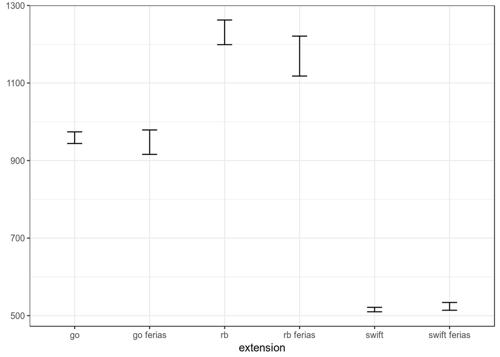

```r
outras.df$extension = c("go ferias",
                        "go",
                        "rb ferias",
                        "rb",
                        "swift ferias",
                        "swift")

outras.df %>%
  ggplot(aes(x = extension,
             ymin = X2.5.,
             ymax = X97.5.)) +
  geom_errorbar(width = .2)
```